# EasyVisa Project

## Context:

Business communities in the United States are facing high demand for human resources, but one of the constant challenges is identifying and attracting the right talent, which is perhaps the most important element in remaining competitive. Companies in the United States look for hard-working, talented, and qualified individuals both locally as well as abroad.

The Immigration and Nationality Act (INA) of the US permits foreign workers to come to the United States to work on either a temporary or permanent basis. The act also protects US workers against adverse impacts on their wages or working conditions by ensuring US employers' compliance with statutory requirements when they hire foreign workers to fill workforce shortages. The immigration programs are administered by the Office of Foreign Labor Certification (OFLC).

OFLC processes job certification applications for employers seeking to bring foreign workers into the United States and grants certifications in those cases where employers can demonstrate that there are not sufficient US workers available to perform the work at wages that meet or exceed the wage paid for the occupation in the area of intended employment.

## Objective:

In FY 2016, the OFLC processed 775,979 employer applications for 1,699,957 positions for temporary and permanent labor certifications. This was a nine percent increase in the overall number of processed applications from the previous year. The process of reviewing every case is becoming a tedious task as the number of applicants is increasing every year.

The increasing number of applicants every year calls for a Machine Learning based solution that can help in shortlisting the candidates having higher chances of VISA approval. OFLC has hired your firm EasyVisa for data-driven solutions. You as a data scientist have to analyze the data provided and, with the help of a classification model:

- Facilitate the process of visa approvals.
- Recommend a suitable profile for the applicants for whom the visa should be certified or denied based on the drivers that significantly influence the case status.

## Data Description

The data contains the different attributes of the employee and the employer. The detailed data dictionary is given below.

- case_id: ID of each visa application
- continent: Information of continent the employee
- education_of_employee: Information of education of the employee
- has_job_experience: Does the employee has any job experience? Y= Yes; N = No
- requires_job_training: Does the employee require any job training? Y = Yes; N = No
- no_of_employees: Number of employees in the employer's company
- yr_of_estab: Year in which the employer's company was established
- region_of_employment: Information of foreign worker's intended region of employment in the US.
- prevailing_wage: Average wage paid to similarly employed workers in a specific occupation in the area of intended employment. The purpose of the prevailing wage is to ensure that the foreign worker is not underpaid compared to other workers offering the same or similar service in the same area of employment.
- unit_of_wage: Unit of prevailing wage. Values include Hourly, Weekly, Monthly, and Yearly.
- full_time_position: Is the position of work full-time? Y = Full Time Position; N = Part Time Position
- case_status: Flag indicating if the Visa was certified or denied

## Importing necessary libraries and data

```python
# Library to suppress warnings or deprecation notes
import warnings
warnings.filterwarnings('ignore')

# Libraries to help with reading and manipulating data
import numpy as np
import pandas as pd

# Libraries to help with data visualization
import matplotlib.pyplot as plt
%matplotlib inline
import seaborn as sns

# Libraries to split data, impute missing values
from sklearn.model_selection import train_test_split
from sklearn.impute import SimpleImputer

# Libraries to import decision tree classifier and different ensemble classifiers
from sklearn.ensemble import BaggingClassifier
from sklearn.ensemble import RandomForestClassifier
from sklearn.ensemble import AdaBoostClassifier, GradientBoostingClassifier
from xgboost import XGBClassifier
from sklearn.ensemble import StackingClassifier
from sklearn.tree import DecisionTreeClassifier
from sklearn.tree import DecisionTreeRegressor
from sklearn.ensemble import BaggingRegressor,RandomForestRegressor, GradientBoostingRegressor, AdaBoostRegressor, StackingRegressor
# Libtune to tune model, get different metric scores
from sklearn import metrics
from sklearn.metrics import confusion_matrix, classification_report, accuracy_score, precision_score, recall_score, f1_score, roc_auc_score
from sklearn.model_selection import GridSearchCV
```

## Data Overview

```python
# Read data in to dataframe
visa = pd.read_csv('EasyVisa.csv')
```

```python
# copying data to another varaible to avoid any changes to original data
data = visa.copy()
```

```python
#Sample data to have a feel of it.
visa.sample(25)
```

|  | case_id | continent | education_of_employee | has_job_experience | requires_job_training | no_of_employees | yr_of_estab | region_of_employment | prevailing_wage | unit_of_wage | full_time_position | case_status |
| --- | --- | --- | --- | --- | --- | --- | --- | --- | --- | --- | --- | --- |
| 9308 | EZYV9309 | North America | Master's | N | N | 1582 | 1995 | Northeast | 335.23 | Hour | Y | Denied |
| 2324 | EZYV2325 | Asia | Bachelor's | Y | N | 3735 | 2013 | West | 45435.38 | Year | Y | Certified |
| 13700 | EZYV13701 | Asia | High School | N | N | 1305 | 1851 | South | 343.57 | Hour | Y | Denied |
| 7602 | EZYV7603 | Asia | Bachelor's | Y | N | 3323 | 1968 | Northeast | 225816.56 | Year | Y | Certified |
| 23222 | EZYV23223 | Asia | Bachelor's | Y | N | 1222 | 1947 | Island | 117067.62 | Year | Y | Certified |
| 2020 | EZYV2021 | Europe | Bachelor's | Y | N | 3265 | 1994 | South | 18190.72 | Year | Y | Certified |
| 14446 | EZYV14447 | Asia | Master's | Y | N | 4470 | 1984 | Northeast | 63850.11 | Year | N | Certified |
| 18557 | EZYV18558 | Asia | High School | Y | N | 1870 | 2004 | West | 85979.34 | Year | Y | Certified |
| 22492 | EZYV22493 | North America | Bachelor's | N | N | 2193 | 2008 | Midwest | 35695.29 | Year | Y | Certified |
| 19337 | EZYV19338 | Asia | Bachelor's | N | N | 2830 | 2014 | Midwest | 48954.35 | Year | Y | Certified |
| 566 | EZYV567 | Asia | Bachelor's | Y | N | 1236 | 1911 | Midwest | 57972.25 | Year | Y | Certified |
| 863 | EZYV864 | Asia | Master's | Y | N | 1817 | 2010 | Midwest | 58434.15 | Year | N | Certified |
| 8961 | EZYV8962 | Asia | Master's | Y | N | 358 | 2009 | South | 105159.80 | Year | N | Certified |
| 5680 | EZYV5681 | Europe | Master's | Y | N | 2094 | 2010 | Northeast | 117448.63 | Year | Y | Certified |
| 6729 | EZYV6730 | Asia | Doctorate | Y | N | 2867 | 2003 | Midwest | 64826.49 | Year | Y | Certified |
| 313 | EZYV314 | Asia | High School | N | N | 29453 | 2005 | Island | 133586.58 | Year | Y | Denied |
| 22007 | EZYV22008 | Asia | Master's | N | N | 3331 | 2005 | Midwest | 116310.52 | Year | Y | Certified |
| 15089 | EZYV15090 | Africa | Bachelor's | N | Y | 389595 | 1989 | West | 24727.94 | Year | Y | Certified |
| 10817 | EZYV10818 | Europe | Bachelor's | Y | Y | 1787 | 2012 | South | 114076.97 | Year | Y | Certified |
| 13548 | EZYV13549 | Asia | Bachelor's | Y | N | 553 | 2014 | South | 81859.29 | Year | Y | Certified |
| 12172 | EZYV12173 | Asia | Bachelor's | N | N | 1407 | 1994 | South | 137.69 | Hour | Y | Certified |
| 14730 | EZYV14731 | Asia | Doctorate | N | N | 1139 | 2006 | Northeast | 76128.75 | Year | Y | Certified |
| 4285 | EZYV4286 | Asia | Master's | Y | N | 82 | 2006 | Northeast | 15082.64 | Year | Y | Certified |
| 15363 | EZYV15364 | Asia | Master's | N | N | 3516 | 1998 | Northeast | 96049.00 | Year | Y | Certified |
| 7165 | EZYV7166 | Asia | Master's | N | N | 4322 | 2005 | West | 145074.67 | Year | Y | Certified |

```python
# Understand the shape of data
visa.shape
```

```
(25480, 12)
```

- Data set has 25480 rows and 12 columns

```python
# Check for duplicated values
visa.duplicated().sum()
```

```
0
```

- There are no duplicate values which is a good sign

```python
#Check for null values
visa.isnull().sum()
```

```
case_id                  0
continent                0
education_of_employee    0
has_job_experience       0
requires_job_training    0
no_of_employees          0
yr_of_estab              0
region_of_employment     0
prevailing_wage          0
unit_of_wage             0
full_time_position       0
case_status              0
dtype: int64
```

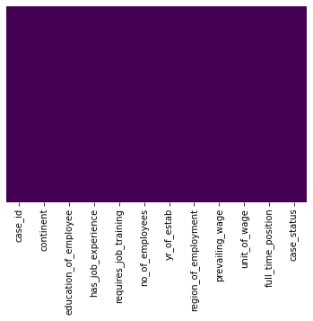

```python
# Above method doesn't show for all data, this chart might help
sns.heatmap(visa.isnull(),yticklabels=False,cbar=False,cmap='viridis')
```

- Data doesn't have null values

```python
visa.info()
```

```
<class 'pandas.core.frame.DataFrame'>
RangeIndex: 25480 entries, 0 to 25479
Data columns (total 12 columns):
 #   Column                 Non-Null Count  Dtype
---  ------                 --------------  -----
 0   case_id                25480 non-null  object
 1   continent              25480 non-null  object
 2   education_of_employee  25480 non-null  object
 3   has_job_experience     25480 non-null  object
 4   requires_job_training  25480 non-null  object
 5   no_of_employees        25480 non-null  int64
 6   yr_of_estab            25480 non-null  int64
 7   region_of_employment   25480 non-null  object
 8   prevailing_wage        25480 non-null  float64
 9   unit_of_wage           25480 non-null  object
 10  full_time_position     25480 non-null  object
 11  case_status            25480 non-null  object
dtypes: float64(1), int64(2), object(9)
memory usage: 2.3+ MB
```

#### Observations

- 3 features are numeric types and 9 String type (object data)
- case_status may be the Y variable

```python
# check for number of unique values in the variables
visa.nunique()
```

```
case_id                  25480
continent                    6
education_of_employee        4
has_job_experience           2
requires_job_training        2
no_of_employees           7105
yr_of_estab                199
region_of_employment         5
prevailing_wage          25454
unit_of_wage                 4
full_time_position           2
case_status                  2
dtype: int64
```

```python
# Convert Categorical values
for feature in visa.columns:
    if visa[feature].dtype == 'object':
        visa[feature] = pd.Categorical(visa[feature])
visa.info()
```

```
<class 'pandas.core.frame.DataFrame'>
RangeIndex: 25480 entries, 0 to 25479
Data columns (total 12 columns):
 #   Column                 Non-Null Count  Dtype
---  ------                 --------------  -----
 0   case_id                25480 non-null  category
 1   continent              25480 non-null  category
 2   education_of_employee  25480 non-null  category
 3   has_job_experience     25480 non-null  category
 4   requires_job_training  25480 non-null  category
 5   no_of_employees        25480 non-null  int64
 6   yr_of_estab            25480 non-null  int64
 7   region_of_employment   25480 non-null  category
 8   prevailing_wage        25480 non-null  float64
 9   unit_of_wage           25480 non-null  category
 10  full_time_position     25480 non-null  category
 11  case_status            25480 non-null  category
dtypes: category(9), float64(1), int64(2)
memory usage: 2.0 MB
```

```python
data.sample(20)
```

|  | case_id | continent | education_of_employee | has_job_experience | requires_job_training | no_of_employees | yr_of_estab | region_of_employment | prevailing_wage | unit_of_wage | full_time_position | case_status |
| --- | --- | --- | --- | --- | --- | --- | --- | --- | --- | --- | --- | --- |
| 2292 | EZYV2293 | Asia | Bachelor's | N | N | 3504 | 2000 | South | 16641.15 | Year | Y | Certified |
| 22863 | EZYV22864 | North America | Bachelor's | Y | N | 5476 | 1999 | West | 16306.10 | Year | Y | Certified |
| 2249 | EZYV2250 | Asia | Bachelor's | Y | N | 2026 | 2005 | South | 153638.30 | Year | Y | Certified |
| 12196 | EZYV12197 | Asia | Master's | Y | N | 4791 | 2008 | Midwest | 152649.95 | Year | Y | Certified |
| 11668 | EZYV11669 | Asia | Bachelor's | Y | Y | 1083 | 1989 | Northeast | 41013.10 | Year | Y | Certified |
| 1016 | EZYV1017 | Asia | Bachelor's | Y | N | 2795 | 2008 | West | 68950.79 | Year | Y | Certified |
| 21169 | EZYV21170 | Asia | Doctorate | Y | N | 48469 | 1976 | Northeast | 242507.42 | Year | Y | Denied |
| 1738 | EZYV1739 | Asia | Master's | N | N | 3861 | 1985 | Midwest | 66445.59 | Year | Y | Certified |
| 20597 | EZYV20598 | Europe | Bachelor's | N | N | 2040 | 2006 | West | 24467.55 | Year | Y | Certified |
| 4180 | EZYV4181 | Asia | Bachelor's | N | N | 3655 | 1975 | West | 178617.39 | Year | Y | Denied |
| 267 | EZYV268 | North America | Master's | Y | N | 2733 | 1960 | West | 108458.31 | Year | Y | Certified |
| 4501 | EZYV4502 | Asia | High School | Y | N | 2058 | 1977 | South | 36456.21 | Year | Y | Denied |
| 703 | EZYV704 | Asia | Bachelor's | N | Y | 1082 | 2009 | Northeast | 90711.57 | Year | Y | Denied |
| 6881 | EZYV6882 | Europe | Bachelor's | N | N | 465 | 1985 | West | 29739.52 | Year | Y | Certified |
| 13625 | EZYV13626 | Asia | Bachelor's | N | N | 1679 | 1968 | Midwest | 125403.68 | Year | Y | Certified |
| 23668 | EZYV23669 | Africa | Doctorate | Y | N | 3050 | 2005 | South | 86515.58 | Year | Y | Certified |
| 12792 | EZYV12793 | Asia | Master's | Y | N | 1593 | 2008 | Midwest | 43571.61 | Year | Y | Certified |
| 7230 | EZYV7231 | Asia | High School | N | N | 795 | 1949 | Northeast | 118802.08 | Year | Y | Denied |
| 24245 | EZYV24246 | Europe | Bachelor's | Y | N | 296 | 2013 | Northeast | 130896.26 | Year | Y | Denied |
| 19519 | EZYV19520 | Asia | Master's | N | Y | 6216 | 2008 | South | 108685.48 | Year | Y | Certified |

## Exploratory Data Analysis (EDA)

- EDA is an important part of any project involving data.
- It is important to investigate and understand the data better before building a model with it.

```python
# Let's look at the statistical summary of the data
pd.set_option(
    "display.float_format", lambda x: "%.2f" % x
)  # to display numbers rounded off to 2 decimal places

visa.describe(include='number').T
```

|  | count | mean | std | min | 25% | 50% | 75% | max |
| --- | --- | --- | --- | --- | --- | --- | --- | --- |
| no_of_employees | 25480.00 | 5667.04 | 22877.93 | -26.00 | 1022.00 | 2109.00 | 3504.00 | 602069.00 |
| yr_of_estab | 25480.00 | 1979.41 | 42.37 | 1800.00 | 1976.00 | 1997.00 | 2005.00 | 2016.00 |
| prevailing_wage | 25480.00 | 74455.81 | 52815.94 | 2.14 | 34015.48 | 70308.21 | 107735.51 | 319210.27 |

```python
visa.describe(exclude='number')# TO check for non-numerical attributes
```

|  | case_id | continent | education_of_employee | has_job_experience | requires_job_training | region_of_employment | unit_of_wage | full_time_position | case_status |
| --- | --- | --- | --- | --- | --- | --- | --- | --- | --- |
| count | 25480 | 25480 | 25480 | 25480 | 25480 | 25480 | 25480 | 25480 | 25480 |
| unique | 25480 | 6 | 4 | 2 | 2 | 5 | 4 | 2 | 2 |
| top | EZYV01 | Asia | Bachelor's | Y | N | Northeast | Year | Y | Certified |
| freq | 1 | 16861 | 10234 | 14802 | 22525 | 7195 | 22962 | 22773 | 17018 |

```python
# function to plot a boxplot and a histogram along the same scale.


def histogram_boxplot(data, feature, figsize=(12, 7), kde=False, bins=None):
    """
    Boxplot and histogram combined

    data: dataframe
    feature: dataframe column
    figsize: size of figure (default (12,7))
    kde: whether to the show density curve (default False)
    bins: number of bins for histogram (default None)
    """
    f2, (ax_box2, ax_hist2) = plt.subplots(
        nrows=2,  # Number of rows of the subplot grid= 2
        sharex=True,  # x-axis will be shared among all subplots
        gridspec_kw={"height_ratios": (0.25, 0.75)},
        figsize=figsize,
    )  # creating the 2 subplots
    sns.boxplot(
        data=data, x=feature, ax=ax_box2, showmeans=True, color="violet"
    )  # boxplot will be created and a star will indicate the mean value of the column
    sns.histplot(
        data=data, x=feature, kde=kde, ax=ax_hist2, bins=bins, palette="winter"
    ) if bins else sns.histplot(
        data=data, x=feature, kde=kde, ax=ax_hist2
    )  # For histogram
    ax_hist2.axvline(
        data[feature].mean(), color="green", linestyle="--"
    )  # Add mean to the histogram
    ax_hist2.axvline(
        data[feature].median(), color="black", linestyle="-"
    )  # Add median to the histogram
```

```python
# function to create labeled barplots


def labeled_barplot(data, feature, perc=False, n=None):
    """
    Barplot with percentage at the top

    data: dataframe
    feature: dataframe column
    perc: whether to display percentages instead of count (default is False)
    n: displays the top n category levels (default is None, i.e., display all levels)
    """

    total = len(data[feature])  # length of the column
    count = data[feature].nunique()
    if n is None:
        plt.figure(figsize=(count + 1, 5))
    else:
        plt.figure(figsize=(n + 1, 5))

    plt.xticks(rotation=90, fontsize=15)
    ax = sns.countplot(
        data=data,
        x=feature,
        palette="Paired",
        order=data[feature].value_counts().index[:n].sort_values(),
    )

    for p in ax.patches:
        if perc == True:
            label = "{:.1f}%".format(
                100 * p.get_height() / total
            )  # percentage of each class of the category
        else:
            label = p.get_height()  # count of each level of the category

        x = p.get_x() + p.get_width() / 2  # width of the plot
        y = p.get_height()  # height of the plot

        ax.annotate(
            label,
            (x, y),
            ha="center",
            va="center",
            size=12,
            xytext=(0, 5),
            textcoords="offset points",
        )  # annotate the percentage

    plt.show()  # show the plot
```